# Проект: Исследование объявлений продажи квартир и определение рыночной стоимости объектов недвижимости

## 3.2. Анализ влияния параметров на стоимость объектов

На данном этапе исследования нам необходимо определить:

- как быстро продавались квартиры;
- факторы, влияющие на общую стоимость объекта;
- среднюю стоимость одного квадратного метра в 10 населенных пунктах с наибольшим числом объявлений;
- среднюю стоимость в зависимости от удаленности от центра.

По условиям проекта мы ищем зависимости общей цены квартиры от установленных параметров.

### 3.2.1. Скорость продажи квартир

Рассмотрим общую информацию и проанализируем данные на гистограмме.

```
Минимальное, максимальное и среднее значение:
```

```
count    22551.000000
mean       151.201011
std        203.487051
min          0.000000
25%         23.000000
50%         72.000000
75%        193.000000
max       1497.000000
Name: days_exposition, dtype: float64
```

```
Медианное значение:
```

```
72.0
```

```
Общее количество строк:
```

```
22551
```

```
График:
```

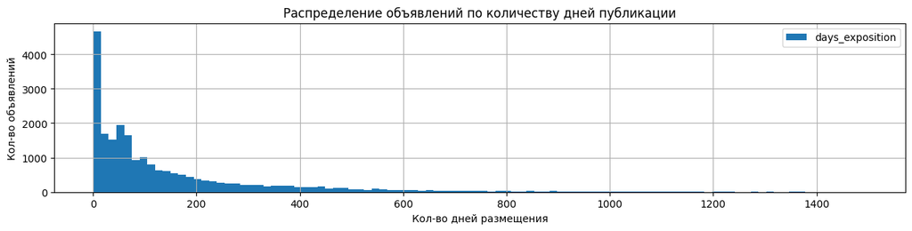

```python
speed_sale = data

describe_info(speed_sale.days_exposition)

plt.title('Распределение объявлений по количеству дней публикации')
plt.xlabel('Кол-во дней размещения')
plt.ylabel('Кол-во объявлений');
```

Заметно большое количество объявлений, которые были размещены менее суток. Возможно, это связано с модерацией или ошибками в объявлениях.

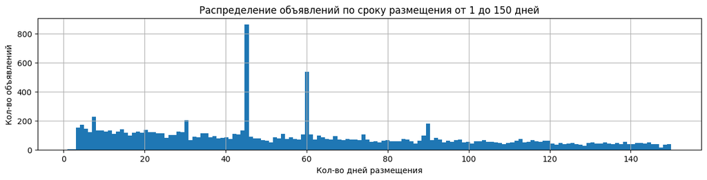

```python
speed_sale['days_exposition'].hist(bins=150, figsize=(15, 3), range = (1,150))

plt.title('Распределение объявлений по сроку размещения от 1 до 150 дней')
plt.xlabel('Кол-во дней размещения')
plt.ylabel('Кол-во объявлений');
```

На графике сроков размещения объявлений в диапазоне с 1-го по 150-й день можно увидеть три пика.

Вероятно, это связано с условиями размещения в сервисе: объявления автоматически закрываются после 45, 60 и 90 дней, и их нужно продлевать вручную.

Исключим эти объявления из исследования и попробуем ответить на вопрос.

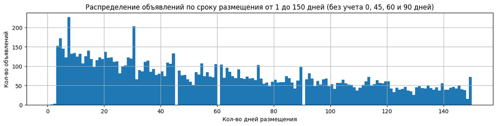

```python
speed_sale = speed_sale.query('days_exposition != [0, 45, 60, 90]')

speed_sale['days_exposition'].hist(bins=150, figsize=(15, 3), range = (0,150))

plt.title('Распределение объявлений по сроку размещения от 1 до 150 дней (без учета 0, 45, 60 и 90 дней)')
plt.xlabel('Кол-во дней размещения')
plt.ylabel('Кол-во объявлений');
```

Проверим данные после фильтрации.

```
Минимальное, максимальное и среднее значение:
```

```
count    18024.000000
mean       184.352197
std        214.805542
min          1.000000
25%         40.000000
50%        107.000000
75%        243.000000
max       1497.000000
Name: days_exposition, dtype: float64
```

```
Медианное значение:
```

```
107.0
```

```
Общее количество строк:
```

```
22551
```

```
График:
```

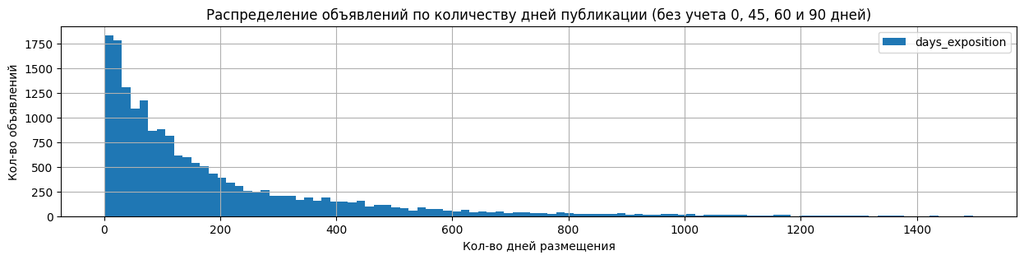

```python
describe_info(speed_sale.days_exposition)

plt.title('Распределение объявлений по количеству дней публикации (без учета 0, 45, 60 и 90 дней)')
plt.xlabel('Кол-во дней размещения')
plt.ylabel('Кол-во объявлений');
```

Изучим изменение средней скорости продаж по годам.

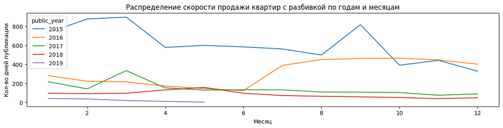

```python
speed_sale.pivot_table(
index = 'public_month',
values = 'days_exposition',
columns = 'public_year',
aggfunc = 'median'
).plot(figsize=(15, 3))

plt.title('Распределение скорости продажи квартир с разбивкой по годам и месяцам')
plt.xlabel('Месяц')
plt.ylabel('Кол-во дней публикации');
```

Конечно, проводить такое сравнение не совсем корректно, поскольку с 2015 года срок продажи квартир составляет четыре года, а с 2018 — всего один год, и, очевидно, значения будут разными.

Если считать длительным сроком продажи показатель в 240 дней, можно посмотреть, какой процент объявлений преодолевает этот порог в каждый год. Составим таблицу, в которой укажем год и процент таких объявлений.

```python
(
    speed_sale.pivot_table(
        index='public_year',
        values='days_exposition',
        aggfunc={'days_exposition': 'count',
                 'days_exposition': lambda x: x[x > 240].count() / x.count() * 100})
    .round(2)
)
```

| public_year | days_exposition |
| --- | --- |
| 2015 | 94.16 |
| 2016 | 51.14 |
| 2017 | 24.55 |
| 2018 | 8.68 |
| 2019 | 0.00 |

Не совсем честно учитывать данные за 2019 и 2018 годы. А вот показатели за 2015, 2016 и 2017 годы могут быть более показательными. Возможно, с течением времени квартиры продаются активнее, а процент длительных продаж уменьшается, а быстрых увеличивается.

И так же посмотрим процент быстрых продаж - это те, что продались в первые 40 дней.

```python
(
    speed_sale.pivot_table(
        index='public_year',
        values='days_exposition',
        aggfunc={'days_exposition': 'count',
                 'days_exposition': lambda x: x[x < 40].count() / x.count() * 100})
    .round(2)
)
```

| public_year | days_exposition |
| --- | --- |
| 2015 | 0.00 |
| 2016 | 4.18 |
| 2017 | 22.03 |
| 2018 | 31.65 |
| 2019 | 73.15 |

Предположение подтверждается. В 2015 и 2016 годах квартиры в течение 40 дней практически не продавались. Начиная с 2017 года, этот показатель значительно вырос, и квартиры стали продаваться в более короткие сроки.

Судя по очищенным и отфильтрованным данным, медианное значение скорости продаж составляет 107 дней, а среднее значение — 184 дня.

На гистограмме выявили три основных пика в 45, 60 и 90 дней. Предположительно, это связано с правилами размещения объявлений на площадке, они закрываются, если не были продлены дальше вручную пользователем.

По остальным показателям квартиры продавались в первые 40 дней достаточно активно, эти продажи можно считать быстрыми, а продажи более 240 дней можно считать долгими. Оптимальный срок продажи находится на уровне 107 дней.

При сравнении изменения скорости продаж по годам видим, что в каждом году есть объекты, которые никак не могут продаться, и срок продажи продолжается 1500 дней на момент исследования. Медианные значения от года к году как же сильно различаются, что говорит и о большом количестве квартир с долгими продажами.

### 3.2.2. Определение факторов влияющих на общую стоимость

В дальнейшем исследовании мы будем анализировать взаимосвязь и искать корреляцию с помощью графиков разброса и функции вычисления коэффициента корреляции Пирсона, где:

- 1 — это высокий уровень положительной/отрицательной корреляции, что означает прямую зависимость между критериями.
- 0 — это отсутствие корреляции.

Автоматизируем построение графика и поиск коэффициента корреляции с помощью функции.

```python
def plot_corr(x_var):
    plt.figure(figsize=(15, 3))
    plt.scatter(data[x_var], data.last_price)

    print('Коэффициент корреляции:', data[x_var].corr(data.last_price))
```

#### 3.2.2.1. Корреляция между общей площадью и стоимостью

```
Коэффициент корреляции: 0.7694143940407453
```

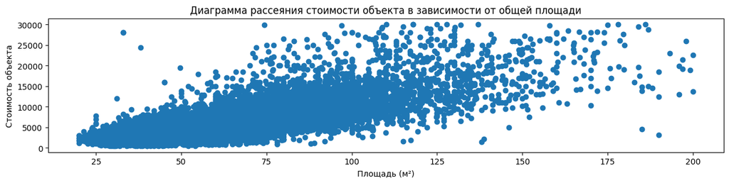

```python
plot_corr('total_area')

plt.title('Диаграмма рассеяния стоимости объекта в зависимости от общей площади')
plt.xlabel('Площадь (м²)')
plt.ylabel('Стоимость объекта');
```

Важно помнить, что корреляция не подразумевает причинно-следственной связи между параметрами, она лишь указывает на наличие статистической взаимосвязи между ними.

#### 3.2.2.2. Корреляция между жилой площадью и стоимостью

```
Коэффициент корреляции: 0.6489825364147602
```

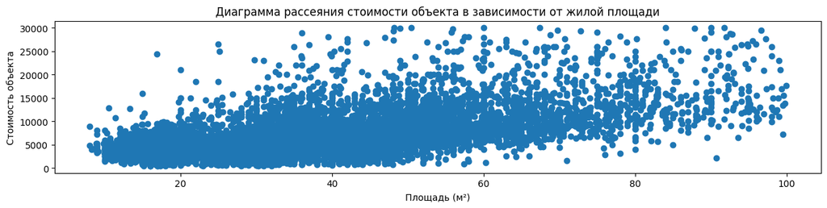

```python
plot_corr('living_area')

plt.title('Диаграмма рассеяния стоимости объекта в зависимости от жилой площади')
plt.xlabel('Площадь (м²)')
plt.ylabel('Стоимость объекта');
```

Коэффициент корреляции, равный 0,64, свидетельствует о наличии сильной положительной взаимосвязи между жилой площадью и стоимостью. Однако эта связь немного слабее, чем у общей площади.

#### 3.2.2.3. Корреляция между кухонной площадью и стоимостью

```
Коэффициент корреляции: 0.5840369801876296
```

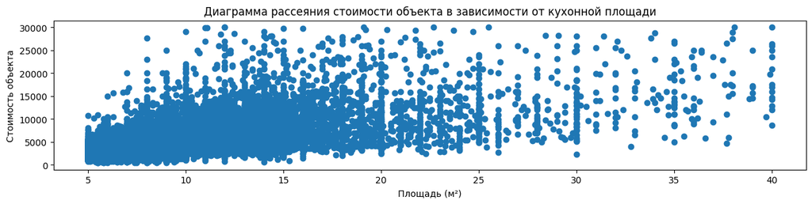

```python
plot_corr('kitchen_area')

plt.title('Диаграмма рассеяния стоимости объекта в зависимости от кухонной площади')
plt.xlabel('Площадь (м²)')
plt.ylabel('Стоимость объекта');
```

#### 3.2.2.4. Корреляция между количеством комнат и стоимостью

```
Коэффициент корреляции: 0.4690170222489141
```

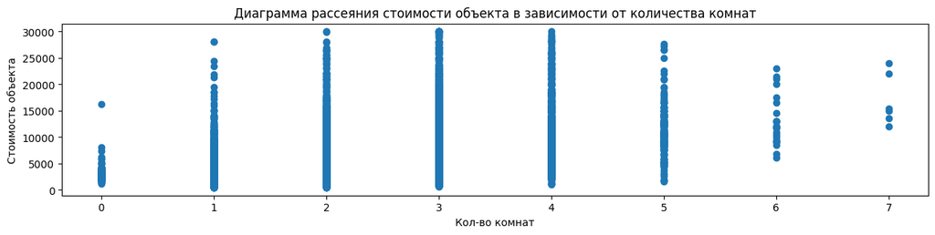

```python
plot_corr('rooms')

plt.title('Диаграмма рассеяния стоимости объекта в зависимости от количества комнат')
plt.xlabel('Кол-во комнат')
plt.ylabel('Стоимость объекта');
```

```python
data.pivot_table(index='rooms', values='last_price', aggfunc=['mean', 'median']).round(2)
```

| rooms | mean last_price | median last_price |
| --- | --- | --- |
| 0 | 3021.75 | 2750.0 |
| 1 | 3819.00 | 3600.0 |
| 2 | 5433.37 | 4775.5 |
| 3 | 7300.91 | 6100.0 |
| 4 | 9807.36 | 8353.0 |
| 5 | 11111.98 | 10500.0 |
| 6 | 12924.07 | 11882.5 |
| 7 | 16973.33 | 15175.0 |

#### 3.2.2.5. Корреляция между типом этажа и стоимостью

```python
type_floor_pt = data.pivot_table(index='type_floor', values='last_price', aggfunc=['mean', 'median', 'count']).round(2)
type_floor_pt.columns = ['mean', 'median', 'count']
type_floor_pt
```

| type_floor | mean | median | count |
| --- | --- | --- | --- |
| другой | 5802.05 | 4758.45 | 16650 |
| первый | 4479.98 | 3900.00 | 2796 |
| последний | 5283.97 | 4250.00 | 3105 |

Невозможно вычислить корреляцию для строковых данных. Однако из таблицы заметно, что средняя стоимость квартир на первом этаже наименьшая. Стоимость квартир на последних этажах также не сильно отличается, а их количество значительно меньше, чем у «других» квартир.

#### 3.2.2.6. Корреляция между датой публикации (день недели, месяц, год) и стоимостью

Изучим корреляцию года размещения объявления и стоимости объектов, рассмотрим медианные значения.

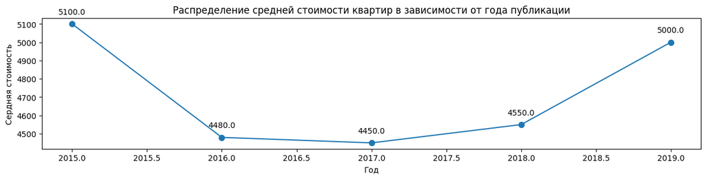

```python
distrib_years = data.pivot_table(index='public_year', values='last_price', aggfunc='median').reset_index()
x = distrib_years['public_year']
y = distrib_years['last_price']

plt.figure(figsize=(15, 3))
plt.plot(x, y, marker='o', markersize=7)

for i in range(len(x)):
    plt.annotate(str(y[i]), xy=(x[i], y[i]), xytext=(0, 10), textcoords='offset points', ha='center', va='bottom')

plt.title('Распределение средней стоимости квартир в зависимости от года публикации')
plt.xlabel('Год')
plt.ylabel('Сердняя стоимость');
```

Большую стоимость 2015 и 2019 года можно объяснить небольшим количеством объявлений. После 2016 года произошло небольшое снижение, а затем средняя цена выросла.

Рассмотрим распределение с учетом месяцев.

```python
data.pivot_table(index = 'public_month', values = 'last_price', columns = 'public_year', aggfunc = 'median')
```

| public_year public_month | 2015 | 2016 | 2017 | 2018 | 2019 |
| --- | --- | --- | --- | --- | --- |
| 1 | 5675.0000 | 5050.0 | 4562.5 | 4300.0 | 4950.0000 |
| 2 | 5275.0000 | 4550.0 | 4550.0 | 4350.0 | 5139.8915 |
| 3 | 5556.2750 | 4400.0 | 4450.0 | 4200.0 | 5000.0000 |
| 4 | 5200.0000 | 4500.0 | 4525.0 | 4500.0 | 5000.0000 |
| 5 | 5050.0000 | 4300.0 | 4500.0 | 4500.0 | 5050.0000 |
| 6 | 4600.0000 | 4400.0 | 4200.0 | 4400.0 | NaN |
| 7 | 5063.3595 | 4285.0 | 4350.0 | 4690.0 | NaN |
| 8 | 5350.0000 | 4100.0 | 4450.0 | 4600.0 | NaN |
| 9 | 5936.5220 | 4790.0 | 4600.0 | 4600.0 | NaN |
| 10 | 4995.0000 | 4999.5 | 4300.0 | 4690.0 | NaN |
| 11 | 5100.0000 | 4400.0 | 4500.0 | 4800.0 | NaN |
| 12 | 4700.0000 | 4600.0 | 4365.0 | 5148.0 | NaN |

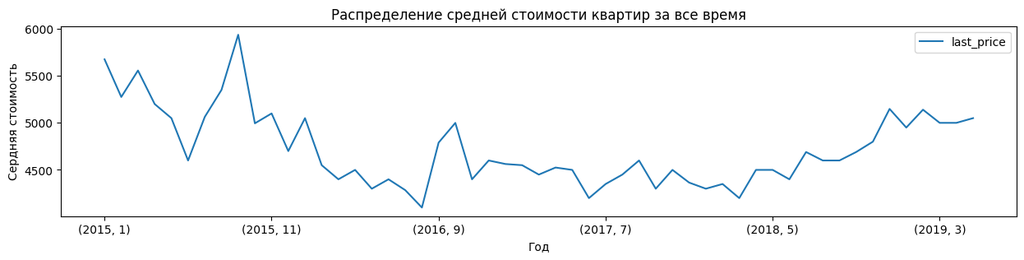

```python
data.pivot_table(index=['public_year', 'public_month'], values='last_price', aggfunc='median').plot(figsize=(15, 3))

plt.title('Распределение средней стоимости квартир за все время')
plt.xlabel('Год')
plt.ylabel('Сердняя стоимость');
```

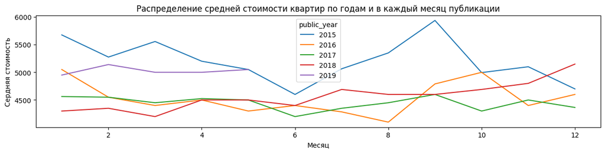

```python
data.pivot_table(
    index = 'public_month',
    values = 'last_price',
    columns = 'public_year',
    aggfunc = 'median'
).plot(figsize=(15, 3))

plt.title('Распределение средней стоимости квартир по годам и в каждый месяц публикации')
plt.xlabel('Месяц')
plt.ylabel('Сердняя стоимость');
```

Теперь картина стала намного яснее. В 2015 году цены были самыми высокими, но потом начали снижаться, лишь иногда немного поднимаясь. В 2018 году цены снова стали расти и сохраняют эту тенденцию до сих пор.

Интересно также посмотреть, как со временем менялись сами квартиры — их общая площадь.

```python
data.pivot_table(index = 'public_month', values = 'total_area', columns = 'public_year', aggfunc = 'median')
```

| public_year public_month | 2015 | 2016 | 2017 | 2018 | 2019 |
| --- | --- | --- | --- | --- | --- |
| 1 | 61.50 | 58.00 | 50.20 | 50.0 | 50.80 |
| 2 | 56.80 | 52.00 | 53.80 | 50.8 | 52.05 |
| 3 | 62.50 | 54.60 | 51.90 | 48.7 | 50.40 |
| 4 | 55.50 | 52.06 | 53.00 | 47.0 | 52.00 |
| 5 | 53.30 | 51.85 | 52.55 | 46.1 | 47.45 |
| 6 | 46.00 | 52.00 | 50.50 | 48.0 | NaN |
| 7 | 60.25 | 49.55 | 49.30 | 51.1 | NaN |
| 8 | 60.00 | 48.20 | 50.65 | 50.6 | NaN |
| 9 | 62.70 | 56.00 | 51.35 | 49.9 | NaN |
| 10 | 58.65 | 55.35 | 49.10 | 50.2 | NaN |
| 11 | 58.00 | 48.20 | 51.00 | 52.0 | NaN |
| 12 | 52.50 | 51.30 | 51.00 | 53.0 | NaN |

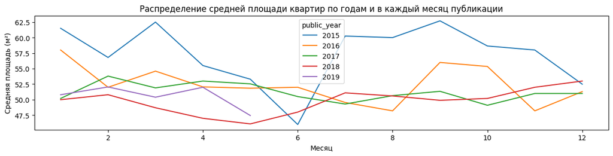

```python
data.pivot_table(
    index = 'public_month',
    values = 'total_area',
    columns = 'public_year',
    aggfunc = 'median'
).plot(figsize=(15, 3))

plt.title('Распределение средней площади квартир по годам и в каждый месяц публикации')
plt.xlabel('Месяц')
plt.ylabel('Средняя площадь (м²)');
```

Общая площадь квартир в продаже со временем уменьшилась. Если в 2015 в среднем квартиры были площадью в 58 метров, то к 2018 году этот показатель упал до 50 метров.

```python
print('Коэффициент корреляции года публикации к общей стоимости:', data['public_year'].corr(data['total_area']))
```

```
Коэффициент корреляции года публикации к общей стоимости: -0.05836736699420088
```

Однако, учитывая, что значение коэффициента близко к нулю, это означает, что связь между этими переменными очень слабая и может быть случайной.

Также рассмотрим показатель цены за квадратный метр, поскольку со временем общая площадь уменьшалась.

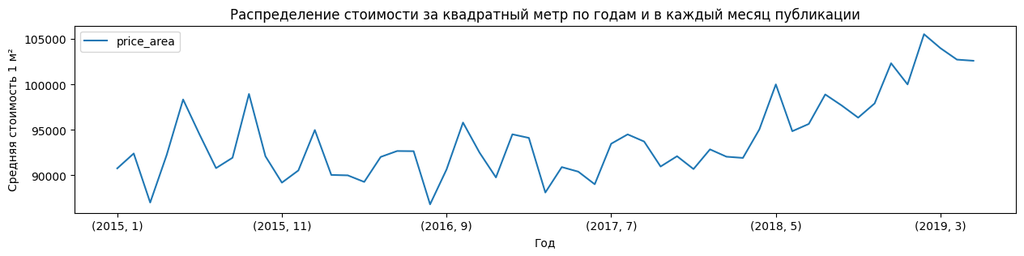

```python
data.pivot_table(index=['public_year', 'public_month'], values='price_area', aggfunc='median').plot(figsize=(15, 3))

plt.title('Распределение стоимости за квадратный метр по годам и в каждый месяц публикации')
plt.xlabel('Год')
plt.ylabel('Средняя стоимость 1 м²');
```

```python
print('Коэффициент корреляции года публикации к стоимости за квадратный метр:', data['public_year'].corr(data['price_area']))
```

```
Коэффициент корреляции года публикации к стоимости за квадратный метр: 0.05851178306486086
```

Наблюдаем очень слабую положительную корреляцию между этими двумя переменными. Связь между этими переменными очень слабая и может быть случайной.

### 3.2.3. Средняя цена квадратного метра в 10 населенных пунктах

Давайте создадим сводную таблицу, где будут указаны десять населённых пунктов, отсортированных по количеству размещённых в них объявлений.

```python
popular_cities = data.pivot_table(index='locality_name', values='last_price', aggfunc=['count', 'mean', 'median']).round(2)
popular_cities.columns = ['count','mean', 'median']
popular_cities = popular_cities.sort_values('count', ascending=False).head(10)

popular_cities
```

| locality_name | count | mean | median |
| --- | --- | --- | --- |
| Санкт-Петербург | 14814 | 6641.65 | 5400.0 |
| поселок Мурино | 576 | 3681.69 | 3400.0 |
| поселок Шушары | 436 | 4119.56 | 3950.0 |
| Всеволожск | 392 | 3789.67 | 3450.0 |
| Пушкин | 349 | 6024.26 | 5150.0 |
| Колпино | 332 | 3859.46 | 3600.0 |
| поселок Парголово | 324 | 4485.50 | 4115.0 |
| Гатчина | 300 | 3488.30 | 3100.0 |
| деревня Кудрово | 298 | 4236.62 | 3790.0 |
| Выборг | 231 | 3173.56 | 2897.0 |

```python
print('Самая высокая средняя стоимость в ТОП-10 населенных пунктов по количеству объявлений:')
display(popular_cities[popular_cities['mean'] == popular_cities['mean'].max()])
print()
print('Самая низкая средняя стоимость в ТОП-10 населенных пунктов по количеству объявлений:')
display(popular_cities[popular_cities['mean'] == popular_cities['mean'].min()])
```

```
Самая высокая средняя стоимость в ТОП-10 населенных пунктов по количеству объявлений:
```

| locality_name | count | mean | median |
| --- | --- | --- | --- |
| Санкт-Петербург | 14814 | 6641.65 | 5400.0 |

```
Самая низкая средняя стоимость в ТОП-10 населенных пунктов по количеству объявлений:
```

| locality_name | count | mean | median |
| --- | --- | --- | --- |
| Выборг | 231 | 3173.56 | 2897.0 |

Построим график с распределением городов по медианной стоимости ТОП-10 населенных пунктов.

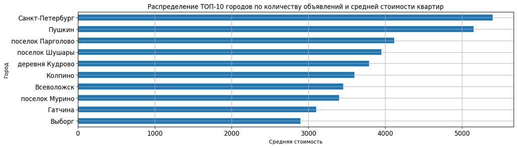

```python
popular_cities['median'].sort_values(ascending = True).plot(
    kind = 'barh',
    figsize = (15,4),
    legend = False,
    fontsize = 12,
    grid = True,
)

plt.title('Распределение ТОП-10 городов по количеству объявлений и средней стоимости квартир')
plt.xlabel('Средняя стоимость')
plt.ylabel('Город');
```

В рейтинге ТОП-10 городов на первом месте оказался Санкт-Петербург, за ним следуют поселок Мурино и поселок Шушары. А на последнем месте расположился город Выборг.

Если рассматривать среднюю стоимость квартир в этих городах, то можно увидеть, что Санкт-Петербург сохраняет свои позиции, за ним следуют Пушкин и поселок Парголово. А город Выборг, как и прежде, остаётся городом с самой низкой средней стоимостью жилья.

### 3.2.4. Изучим зависимость расстояния до центра города на стоимость объекта

```python
# установим заглушку на пусые значения и изменим тип данных

data['city_centers_nearest_km'] = data['city_centers_nearest_km'].fillna(100)
data['city_centers_nearest_km'] = data['city_centers_nearest_km'].astype('int')
```

Создадим новую переменную, оставим только объекты в Санкт-Петербурге и исключим пустые значения, на которые мы поставили заглушку.

```python
city_km_price = (
    data.query('locality_name == "Санкт-Петербург" and city_centers_nearest_km !=100')
    .pivot_table(index = 'city_centers_nearest_km', values = 'last_price', aggfunc = ['mean', 'median', 'count'])
    .round(2)
)

city_km_price.columns = ['mean', 'median', 'count']
city_km_price
```

| city_centers_nearest_km | mean | median | count |
| --- | --- | --- | --- |
| 0 | 9261.82 | 8000.00 | 11 |
| 1 | 11490.96 | 9990.00 | 157 |
| 2 | 10386.99 | 9050.00 | 242 |
| 3 | 9204.30 | 8000.00 | 304 |
| 4 | 9774.59 | 8500.00 | 595 |
| 5 | 10336.96 | 8700.00 | 790 |
| 6 | 9196.08 | 7995.00 | 512 |
| 7 | 9124.10 | 6990.00 | 359 |
| 8 | 8536.30 | 7120.00 | 559 |
| 9 | 6681.15 | 5270.00 | 570 |
| 10 | 6290.85 | 5000.00 | 698 |
| 11 | 5907.59 | 4994.00 | 1120 |
| 12 | 5756.96 | 4950.00 | 1572 |
| 13 | 6013.01 | 5200.00 | 1426 |
| 14 | 5548.60 | 4870.00 | 1255 |
| 15 | 5669.74 | 4900.00 | 1530 |
| 16 | 5319.19 | 4750.00 | 1244 |
| 17 | 5187.07 | 4565.00 | 858 |
| 18 | 4840.04 | 4300.00 | 255 |
| 19 | 5051.41 | 4500.00 | 156 |
| 20 | 5870.71 | 5500.00 | 45 |
| 21 | 5419.22 | 5210.00 | 114 |
| 22 | 5377.73 | 4925.00 | 200 |
| 23 | 4702.04 | 4450.00 | 82 |
| 24 | 3854.43 | 3480.00 | 26 |
| 25 | 4052.84 | 3794.88 | 26 |
| 26 | 4014.29 | 3355.00 | 43 |
| 27 | 8300.00 | 8300.00 | 2 |
| 28 | 5026.43 | 4990.00 | 7 |
| 29 | 4236.67 | 4535.00 | 6 |

Построим график и сравним среднее и медианное значения удаленности от центра.

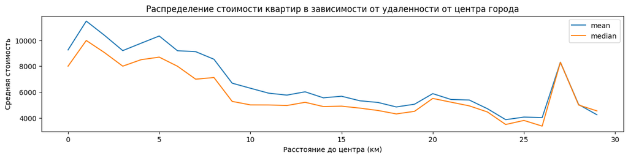

```python
city_km_price[['mean', 'median']].plot(figsize=(15, 3))

plt.title('Распределение стоимости квартир в зависимости от удаленности от центра города')
plt.xlabel('Расстояние до центра (км)')
plt.ylabel('Средняя стоимость');
```

В таблице и на графике заметен резкий скачок значений стоимости на 27 километре. На 27 километре всего 2 квартиры, притом их стоимость на уровне 6 километров от центра. Рассмотрим их подробнее.

```python
data.query('locality_name == "Санкт-Петербург" and city_centers_nearest_km == 27')\
[['city_centers_nearest_km', 'total_area', 'living_area', 'rooms', 'last_price']]
```

|  | city_centers_nearest_km | total_area | living_area | rooms | last_price |
| --- | --- | --- | --- | --- | --- |
| 748 | 27 | 74.0 | 30.0 | 2 | 14350.0 |
| 5961 | 27 | 32.0 | 16.5 | 1 | 2250.0 |

Видим, что эти два объекта стоят 2 и 14 млн., из-за чего средняя стоимость очень высока. Для сравнения посмотрим на значения на 28-м километре. Возможно, проблема лишь в малом количестве объектов.

```python
data.query('locality_name == "Санкт-Петербург" and city_centers_nearest_km == 28')\
[['city_centers_nearest_km', 'total_area', 'living_area', 'rooms', 'last_price']]
```

|  | city_centers_nearest_km | total_area | living_area | rooms | last_price |
| --- | --- | --- | --- | --- | --- |
| 814 | 28 | 111.0 | 63.0 | 3 | 7600.0 |
| 1111 | 28 | 38.0 | 16.0 | 1 | 4072.0 |
| 9572 | 28 | 43.0 | 18.0 | 1 | 3413.0 |
| 17798 | 28 | 71.0 | 42.0 | 3 | 4990.0 |
| 18941 | 28 | 39.0 | 16.0 | 1 | 3666.0 |
| 22916 | 28 | 64.0 | 33.0 | 2 | 5144.0 |
| 23145 | 28 | 92.0 | 46.0 | 3 | 6300.0 |

На 28-м километре цены варьируются от 3,5 млн до 7,6 млн. Видимо, объекты на 27-м км с самой низкой и самой высокой ценой являются исключением из общей картины. Исключим их из анализа и построим новый график.

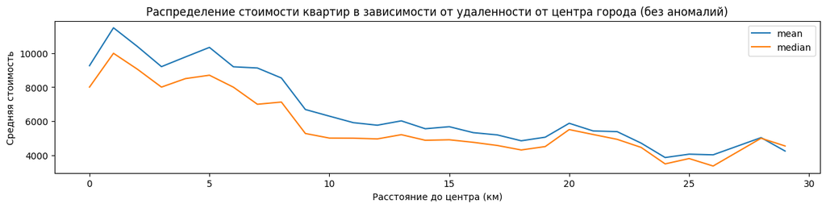

```python
city_km_price = city_km_price.query('city_centers_nearest_km != 27')
city_km_price[['mean', 'median']].plot(figsize=(15, 3))

plt.title('Распределение стоимости квартир в зависимости от удаленности от центра города (без аномалий)')
plt.xlabel('Расстояние до центра (км)')
plt.ylabel('Средняя стоимость');
```

Дополнительно построим график распределения количества объявлений, в зависимости от удаления от центра.

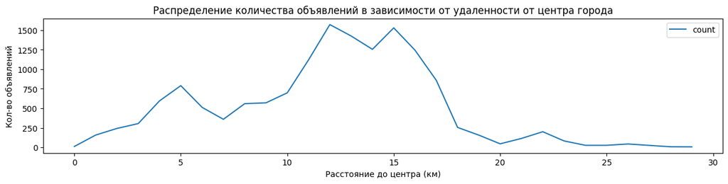

```python
city_km_price[['count']].plot(figsize=(15, 3))

plt.title('Распределение количества объявлений в зависимости от удаленности от центра города')
plt.xlabel('Расстояние до центра (км)')
plt.ylabel('Кол-во объявлений');
```

Видим 2 пика в районе 5 км и 10-17 км от центра. При этом высокие цены только в районе 1-10 км.

Больше всего объявлений находятся в районе 5 и 10-17 км от центра города. А самая высокая средняя стоимость от 1 до 10 км.

Если вы покупаете квартиру, то лучше выбирать ее в 10-20 км от центра, цены там ниже и количество предложений намного больше. А вот до 10 км предложений в среднем достаточно, но там крайне высокие цены.

# 4. Заключение

В ходе исследования объявлений о продаже квартир в Санкт-Петербурге мы проанализировали рыночную стоимость объектов недвижимости. Обнаружили и устранили множество ошибок и неточностей в данных, что позволило улучшить качество для анализа. Также мы рассчитали расстояние от центра города, определили тип квартир в зависимости от этажа и задали классификацию.

Исследование проводилось на основе данных, собранных с 1 января 2015 года по 3 мая 2019 года.

Полученные результаты могут быть полезны для потенциальных покупателей и продавцов недвижимости, а также для инвесторов и застройщиков. Они позволяют лучше понимать механизмы формирования цен на рынке недвижимости и выбирать оптимальные стратегии для покупки или продажи квартир.

Общие данные иследования приведены в таблицах:

1. Ключевые параметры влияющие на стоиость квартир.

[output not shown]

2. Скорость продажи квартир в каждом году, с указанием процента быстрых и долгих продаж.

[output not shown]

3. Коэффициент корреляции между разными параметрами и стоимостью.

[output not shown]

4. Средняя стоимость в ТОП-10 населенных пунктах по количеству размещенных объявлений.

   4.1. Топ 3 города из 10 по количеству объявлений.

[output not shown]

```
4.2. Топ 3 города из 10 по средней стоимости.
```

[output not shown]

5. Разделение стоимости и количества объявлений в зависимости от зоны удаленности от центра города.

[output not shown]